# MIMIC-III Diagnoses Tables

efg | 2019-01-06

# 1 Fact and Dimension tables

The MIMIC-III schema shows a fact table, [diagnoses_icd](https://mit-lcp.github.io/mimic-schema-spy/tables/diagnoses_icd.html), with a record for each patient-admission-diagnosis. The details of the related ICD 9 diagnosis codes are in the dimension table, [d_icd_diagnoses](https://mit-lcp.github.io/mimic-schema-spy/tables/d_icd_diagnoses.html).

# 2 Setup

```r
plotCaptionLeft  <- "MIMIC-III v1.4"
plotCaptionRight <- paste("efg", format(Sys.time(), "%Y-%m-%d"))
```

## 2.1 Packages

```r
library(DBI)
library(RPostgres)
library(tidyverse)
```

```r
library(dbplyr, warn.conflicts=FALSE)
library(kableExtra)
library(ggplot2)
library(writexl)
```

## 2.2 Helper function

```r
Show <- function(data, caption=NULL)
{
  data                            %>%
  kable("html", caption=caption)  %>%
  kable_styling(bootstrap_options = c("striped", "bordered", "condensed"),
                position = "left", full_width = FALSE)
}
```

## 2.3 Open database

```r
MimicDB <- dbConnect(RPostgres::Postgres(),
                     dbname   = "mimic",
                     user     = Sys.getenv("MIMIC_User"),
                     password = Sys.getenv("MIMIC_Password"),
                     bigint   = "integer",                      # RPostgres
                     options  = "-c search_path=mimiciii")

dimDiagnoses   <- tbl(MimicDB, in_schema("mimiciii", "d_icd_diagnoses"))
factDiagnoses  <- tbl(MimicDB, in_schema("mimiciii", "diagnoses_icd"))

factAdmissions <- tbl(MimicDB, in_schema("mimiciii", "admissions"))
factPatients   <- tbl(MimicDB, in_schema("mimiciii", "patients"))
```

# 3 Tables

## 3.1 Dimension table: d_icd_diagnoses

### 3.1.1 Fields

```r
dbListFields(MimicDB, "d_icd_diagnoses")
```

```
[1] "row_id"      "icd9_code"   "short_title" "long_title"
```

### 3.1.2 Record count

```r
dimDiagnoses  %>%
  count()     %>%
  Show()
```

| n |
| --- |
| 14567 |

The schema says this table has 14,710 records, but the raw data file D_ICD_DIAGNOSES.csv has 14,567 records. The value above is correct.

### 3.1.3 Sample records

```r
dimDiagnoses          %>%
  arrange(icd9_code)  %>%
  head(10)            %>%
  Show(caption = "Sample Records from Diagnoses Dimension Table, d_icd_diagnoses")
```

Sample Records from Diagnoses Dimension Table, d_icd_diagnoses

| row_id | icd9_code | short_title | long_title |
| --- | --- | --- | --- |
| 233 | 0010 | Cholera d/t vib cholerae | Cholera due to vibrio cholerae |
| 234 | 0011 | Cholera d/t vib el tor | Cholera due to vibrio cholerae el tor |
| 235 | 0019 | Cholera NOS | Cholera, unspecified |
| 236 | 0020 | Typhoid fever | Typhoid fever |
| 237 | 0021 | Paratyphoid fever a | Paratyphoid fever A |
| 238 | 0022 | Paratyphoid fever b | Paratyphoid fever B |
| 239 | 0023 | Paratyphoid fever c | Paratyphoid fever C |
| 240 | 0029 | Paratyphoid fever NOS | Paratyphoid fever, unspecified |
| 241 | 0030 | Salmonella enteritis | Salmonella gastroenteritis |
| 242 | 0031 | Salmonella septicemia | Salmonella septicemia |

## 3.2 Fact table: diagnoses_icd

### 3.2.1 Fields

```r
dbListFields(MimicDB, "diagnoses_icd")
```

```
[1] "row_id"     "subject_id" "hadm_id"    "seq_num"    "icd9_code"
```

### 3.2.2 Record count

```r
factDiagnoses %>%
  summarize(n = n(),
            diagnosesCodes = n_distinct(icd9_code)) %>%
  Show()
```

| n | diagnosesCodes |
| --- | --- |
| 651047 | 6984 |

A number of fact records are missing icd9_code values

```r
factDiagnoses               %>%
  select(icd9_code)         %>%
  collect()                 %>%
  summarize(icd9NAs = sum(is.na(icd9_code)))  %>%
  Show()
```

| icd9NAs |
| --- |
| 47 |

### 3.2.3 Sample records

```r
factDiagnoses  %>%
  arrange(subject_id, row_id)  %>%  # control order
  head(5)                      %>%
  Show(caption = "Sample Records from Diagnoses Fact Table, diagnoses_icd")
```

Sample Records from Diagnoses Fact Table, diagnoses_icd

| row_id | subject_id | hadm_id | seq_num | icd9_code |
| --- | --- | --- | --- | --- |
| 1 | 2 | 163353 | 1 | V3001 |
| 2 | 2 | 163353 | 2 | V053 |
| 3 | 2 | 163353 | 3 | V290 |
| 4 | 3 | 145834 | 1 | 0389 |
| 5 | 3 | 145834 | 2 | 78559 |

### 3.2.4 Fields

#### 3.2.4.1 seq_num: diagnosis priority

```r
priorityCounts <-
  factDiagnoses      %>%
  group_by(seq_num)  %>%
  count()            %>%
  collect()

priorityCounts       %>%
  Show()             %>%
  scroll_box(height = "400px")
```

| seq_num | n |
| --- | --- |
| 1 | 58929 |
| 2 | 58555 |
| 3 | 57498 |
| 4 | 54699 |
| 5 | 51421 |
| 6 | 47914 |
| 7 | 44202 |
| 8 | 40327 |
| 9 | 36360 |
| 10 | 27258 |
| 11 | 24546 |
| 12 | 21877 |
| 13 | 19333 |
| 14 | 16999 |
| 15 | 14764 |
| 16 | 12759 |
| 17 | 10894 |
| 18 | 9186 |
| 19 | 7725 |
| 20 | 6438 |
| 21 | 5332 |
| 22 | 4390 |
| 23 | 3643 |
| 24 | 3001 |
| 25 | 2491 |
| 26 | 2075 |
| 27 | 1702 |
| 28 | 1405 |
| 29 | 1133 |
| 30 | 930 |
| 31 | 736 |
| 32 | 598 |
| 33 | 480 |
| 34 | 377 |
| 35 | 316 |
| 36 | 251 |
| 37 | 186 |
| 38 | 150 |
| 39 | 120 |
| NA | 47 |

Sequence 1 is the primary code.

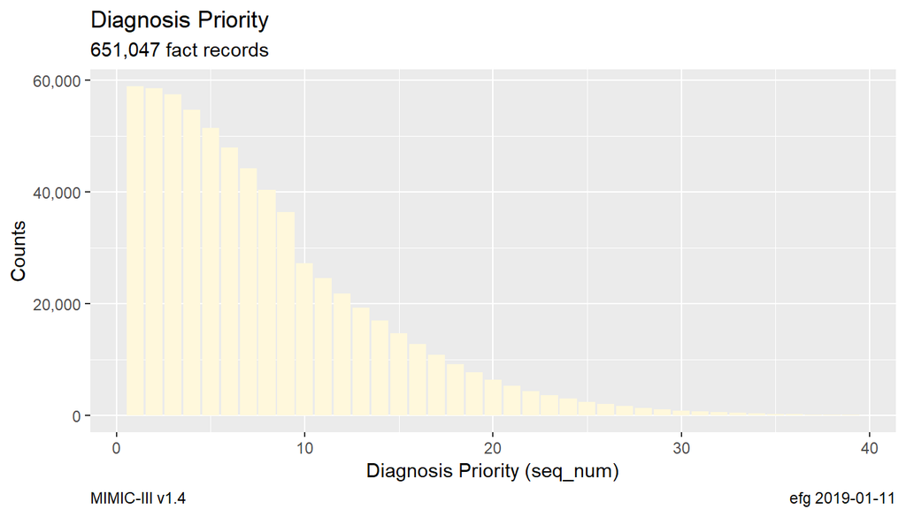

```r
ggplot(data = priorityCounts, aes(x = seq_num, y = n))  +
  geom_bar(stat = "identity", fill = "cornsilk")        +
  scale_y_continuous(labels = scales::comma)            +
  labs(title = "Diagnosis Priority",
       subtitle = paste(format(sum(priorityCounts$n, na.rm=TRUE),
                               big.mark = ","), "fact records"),
       x = "Diagnosis Priority (seq_num)",
       y = "Counts",
       caption=c(plotCaptionLeft, plotCaptionRight))    +
  theme(plot.caption = element_text(hjust=c(0.0,1.0)))
```

## 3.3 Join diagnoses tables

Add dimension information to fact table so word descriptions can be viewed instead of codes.

### 3.3.1 inner_join

```r
factDiagnoses                                 %>%
  inner_join(dimDiagnoses, by = "icd9_code")  %>%
  head()                                      %>%
  collect()                                   %>%
  str()
```

```
Classes 'tbl_df', 'tbl' and 'data.frame':   6 obs. of  8 variables:
 $ row_id.x   : int  307770 497329 513229 398507 579783 408925
 $ subject_id : int  27367 65733 69141 44437 83908 46693
 $ hadm_id    : int  136441 168926 136542 181557 180356 183574
 $ seq_num    : int  7 9 1 10 3 4
 $ icd9_code  : chr  "0030" "0030" "0031" "0038" ...
 $ row_id.y   : int  241 241 242 249 249 250
 $ short_title: chr  "Salmonella enteritis" "Salmonella enteritis" "Salmonella septicemia" "Salmonella infection NEC" ...
 $ long_title : chr  "Salmonella gastroenteritis" "Salmonella gastroenteritis" "Salmonella septicemia" "Other specified salmonella infections" ...
```

```r
factDiagnoses                                 %>%
  inner_join(dimDiagnoses, by = "icd9_code")  %>%
  arrange(subject_id, row_id.x)               %>%  # control order
  head(5)                                     %>%
  collect()                                   %>%
  Show(caption = "Sample Diagnoses Records (Fact + Dimension)")
```

Sample Diagnoses Records (Fact + Dimension)

| row_id.x | subject_id | hadm_id | seq_num | icd9_code | row_id.y | short_title | long_title |
| --- | --- | --- | --- | --- | --- | --- | --- |
| 1 | 2 | 163353 | 1 | V3001 | 13695 | Single lb in-hosp w cs | Single liveborn, born in hospital, delivered by cesarean section |
| 2 | 2 | 163353 | 2 | V053 | 12202 | Need prphyl vc vrl hepat | Need for prophylactic vaccination and inoculation against viral hepatitis |
| 3 | 2 | 163353 | 3 | V290 | 13688 | NB obsrv suspct infect | Observation for suspected infectious condition |
| 4 | 3 | 145834 | 1 | 0389 | 660 | Septicemia NOS | Unspecified septicemia |
| 5 | 3 | 145834 | 2 | 78559 | 12992 | Shock w/o trauma NEC | Other shock without mention of trauma |

Why were so many fact records lost in join?

```r
factDiagnoses                                 %>%
  inner_join(dimDiagnoses, by = "icd9_code")  %>%
  count()                                     %>%
  Show()
```

| n |
| --- |
| 634709 |

```r
dimICD9codes <-
  dimDiagnoses       %>%
  select(icd9_code)  %>%
  distinct()         %>%
  arrange(icd9_code) %>%
  collect()

nrow(dimICD9codes)
```

```
## [1] 14567
```

```r
factICD9codes <-
  factDiagnoses      %>%
  select(icd9_code)  %>%
  distinct()         %>%
  arrange(icd9_code) %>%
  collect()

nrow(factICD9codes)
```

```
## [1] 6985
```

Fact codes not in dimension list

The dimension table could likely be supplemented with information about ICD-9-CM codes from the [National Center for Health Statistics](https://www.cdc.gov/nchs/icd/icd9cm.htm).

```r
factNotInDim <- setdiff(factICD9codes$icd9_code, dimICD9codes$icd9_code)
factNotInDim
```

```
##   [1] "0414"  "1730"  "1731"  "1732"  "1733"  "1734"  "1735"  "1736"
##   [9] "1737"  "1738"  "1739"  "2333"  "2387"  "2520"  "2554"  "2740"
##  [17] "2750"  "2765"  "2766"  "2773"  "2778"  "2794"  "2824"  "2840"
##  [25] "2841"  "2848"  "2865"  "2873"  "2874"  "2880"  "2898"  "3108"
##  [33] "3234"  "3236"  "3238"  "3337"  "3370"  "3483"  "3488"  "3578"
##  [41] "3580"  "3592"  "4251"  "4440"  "4538"  "4582"  "4781"  "4881"
##  [49] "5118"  "5128"  "5163"  "5185"  "5191"  "5233"  "5234"  "5280"
##  [57] "5302"  "5640"  "5672"  "5678"  "585"   "5888"  "5968"  "5996"
##  [65] "5997"  "6000"  "6002"  "6009"  "6082"  "6118"  "6168"  "6180"
##  [73] "6188"  "6213"  "6221"  "6951"  "7070"  "71970" "7299"  "7473"
##  [81] "7523"  "7583"  "7662"  "7671"  "7687"  "7701"  "7708"  "7718"
##  [89] "7721"  "7758"  "7775"  "7793"  "7798"  "7806"  "7809"  "7845"
##  [97] "7863"  "7872"  "7876"  "7895"  "7902"  "7931"  "7955"  "7990"
## [105] "7992"  "8501"  "9690"  "9697"  "9708"  "9952"  "9964"  "9973"
## [113] "9974"  "9980"  "9983"  "9993"  "9994"  "9995"  "9996"  "9998"
## [121] "E888"  "E927"  "V017"  "V109"  "V122"  "V135"  "V138"  "V152"
## [129] "V155"  "V174"  "V181"  "V403"  "V451"  "V461"  "V51"   "V581"
## [137] "V583"  "V608"  "V610"  "V640"  "V644"  "V721"  "V854"  NA
```

Many dimension records are not referenced by a fact table.

```r
dimNotInFact <- setdiff(dimICD9codes$icd9_code, factICD9codes$icd9_code)
length(dimNotInFact)
```

```
## [1] 7726
```

### 3.3.2 left_join

Keep all diagnosis codes even if not in dimension table using a `left_join`. This will create NULLs for diagnosis descriptions.

```r
factDiagnoses                                 %>%
  left_join(dimDiagnoses, by = "icd9_code")   %>%
  count()                                     %>%
  Show()
```

| n |
| --- |
| 651047 |

How many were given NULL short_titles?

```r
factDiagnoses                                 %>%
  left_join(dimDiagnoses, by = "icd9_code")   %>%
  filter(is.na(short_title))                  %>%
  count()                                     %>%
  Show()
```

| n |
| --- |
| 16338 |

Examples with missing short_titles

```r
factDiagnoses                                 %>%
  left_join(dimDiagnoses, by = "icd9_code")   %>%
  filter(is.na(short_title))                  %>%
  head(2)                                     %>%
  Show()
```

| row_id.x | subject_id | hadm_id | seq_num | icd9_code | row_id.y | short_title | long_title |
| --- | --- | --- | --- | --- | --- | --- | --- |
| 1524 | 117 | 140784 | 2 | 7895 | NA | NA | NA |
| 1529 | 117 | 140784 | 7 | 2765 | NA | NA | NA |

So, normally we’ll use a left_join with `dimDiagnoses` and missing labels will be NULL.

# 4 Summaries

## 4.1 Summarize Diagnoses Counts

```r
diagnosesCounts <-
  factDiagnoses                     %>%
  filter(!is.na(icd9_code))         %>%
  group_by(icd9_code)               %>%
  count()                           %>%
  ungroup()                         %>%
  left_join(dimDiagnoses,
             by = "icd9_code")      %>%
  select(n, everything(), -row_id)  %>%
  arrange(desc(n))                  %>%
  collect()

nrow(diagnosesCounts)
```

```
[1] 6984
```

Many of the ICD 9 diagnoses codes in the dimension table are never referenced.

### 4.1.1 Top 10

```r
diagnosesCounts %>% head(10) %>% Show()
```

| n | icd9_code | short_title | long_title |
| --- | --- | --- | --- |
| 20703 | 4019 | Hypertension NOS | Unspecified essential hypertension |
| 13111 | 4280 | CHF NOS | Congestive heart failure, unspecified |
| 12891 | 42731 | Atrial fibrillation | Atrial fibrillation |
| 12429 | 41401 | Crnry athrscl natve vssl | Coronary atherosclerosis of native coronary artery |
| 9119 | 5849 | Acute kidney failure NOS | Acute kidney failure, unspecified |
| 9058 | 25000 | DMII wo cmp nt st uncntr | Diabetes mellitus without mention of complication, type II or unspecified type, not stated as uncontrolled |
| 8690 | 2724 | Hyperlipidemia NEC/NOS | Other and unspecified hyperlipidemia |
| 7497 | 51881 | Acute respiratry failure | Acute respiratory failure |
| 6555 | 5990 | Urin tract infection NOS | Urinary tract infection, site not specified |
| 6326 | 53081 | Esophageal reflux | Esophageal reflux |

## 4.2 Summarize Diagnoses as Primary or Secondary

```r
diagnosesPrimaryCounts <-
  factDiagnoses                     %>%
  filter(!is.na(icd9_code))         %>%
  mutate(priority = ifelse(seq_num == 1,
                           "Primary",
                           "Secondary"))  %>%
  group_by(icd9_code, priority)     %>%
  count()                           %>%
  ungroup()                         %>%
  collect()                         %>%
  spread(priority, n, fill=0)       %>%
  mutate(n = Primary + Secondary)   %>%
  left_join(dimDiagnoses,
            by = "icd9_code",
            copy = TRUE)            %>%
  select(n, Primary, Secondary,
         everything(), -row_id)     %>%
  arrange(desc(n))

nrow(diagnosesPrimaryCounts)
```

```
[1] 6984
```

### 4.2.1 Top 10 Primary Diagnoses

```r
diagnosesPrimaryCounts    %>%
  arrange(desc(Primary))  %>%
  head(10)                %>%
  Show()
```

| n | Primary | Secondary | icd9_code | short_title | long_title |
| --- | --- | --- | --- | --- | --- |
| 3566 | 3566 | 0 | V3000 | Single lb in-hosp w/o cs | Single liveborn, born in hospital, delivered without mention of cesarean section |
| 12429 | 3498 | 8931 | 41401 | Crnry athrscl natve vssl | Coronary atherosclerosis of native coronary artery |
| 2758 | 2757 | 1 | V3001 | Single lb in-hosp w cs | Single liveborn, born in hospital, delivered by cesarean section |
| 3725 | 2069 | 1656 | 0389 | Septicemia NOS | Unspecified septicemia |
| 3055 | 1751 | 1304 | 41071 | Subendo infarct, initial | Subendocardial infarction, initial episode of care |
| 2550 | 1140 | 1410 | 4241 | Aortic valve disorder | Aortic valve disorders |
| 7497 | 1127 | 6370 | 51881 | Acute respiratry failure | Acute respiratory failure |
| 1367 | 1030 | 337 | 431 | Intracerebral hemorrhage | Intracerebral hemorrhage |
| 1000 | 998 | 2 | V3101 | Twin-mate lb-in hos w cs | Twin birth, mate liveborn, born in hospital, delivered by cesarean section |
| 4839 | 725 | 4114 | 486 | Pneumonia, organism NOS | Pneumonia, organism unspecified |

Save for further study

```r
write_xlsx(diagnosesPrimaryCounts, "MIMIC-III-Diagnoses-Counts.xlsx")
```

## 4.3 Summarize Diagnoses by Age Intervals

```r
admitAges <-
  factDiagnoses                               %>%
  inner_join(factPatients,
             by = "subject_id")               %>%
  inner_join(factAdmissions,
             by = c("subject_id",
                    "hadm_id"))                           %>%
  select(subject_id, hadm_id, icd9_code, dob, admittime)  %>%
  collect()                                               %>%
  mutate(    # collect from database and use R for mutate
          delta         = admittime - dob,
          admitAgeYears = as.numeric((admittime - dob)) / ( 365.25 * 86400),  # seconds
          ageInterval   = pmin(90, 10 * admitAgeYears %/% 10)    # age decades; 90 is 90+
          )

nrow(admitAges)
```

```
[1] 651047
```

Sample records

```r
admitAges %>%
  head(2) %>%
  Show()
```

| subject_id | hadm_id | icd9_code | dob | admittime | delta | admitAgeYears | ageInterval |
| --- | --- | --- | --- | --- | --- | --- | --- |
| 109 | 172335 | 40301 | 2117-08-07 | 2141-09-18 10:32:00 | 761049120 secs | 24.11619 | 20 |
| 109 | 172335 | 486 | 2117-08-07 | 2141-09-18 10:32:00 | 761049120 secs | 24.11619 | 20 |

Counts by age intervals

```r
table(admitAges$ageInterval)
```

```
     0     10     20     30     40     50     60     70     80     90
 46791   2821  17857  25990  56645 101425 131705 131789 101652  34372
```

Interval percentages

```r
round(100 * table(admitAges$ageInterval) / nrow(admitAges), 2)
```

```
    0    10    20    30    40    50    60    70    80    90
 7.19  0.43  2.74  3.99  8.70 15.58 20.23 20.24 15.61  5.28
```

Here “0” means 0-9, “10” means 10-19, …, “80”" means 80-89, “90”" means 90+

Side note: Decile intervals – if balanced groups are wanted

```r
quantile(admitAges$admitAgeYears,
         c(0.00, 0.10, 0.20, 0.30, 0.40, 0.50, 0.60, 0.70, 0.80, 0.90, 1.00))  %>% round(1)
```

```
   0%   10%   20%   30%   40%   50%   60%   70%   80%   90%  100%
  0.0  28.6  47.2  54.9  60.7  65.8  70.7  75.8  80.4  85.5 236.6
```

Admit ages are skewed to 50+ intervals

### 4.3.1 Admit Age Density

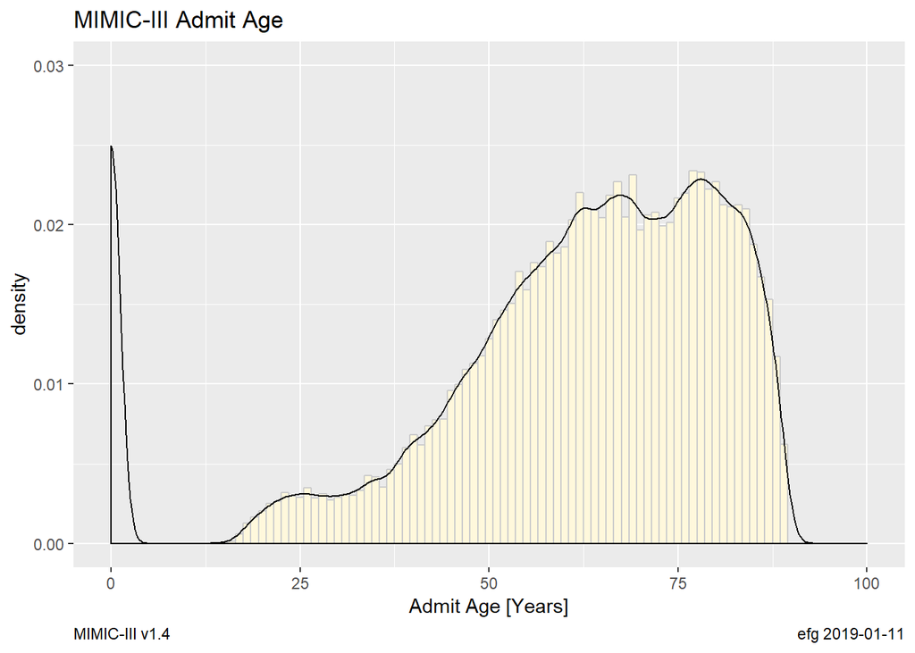

```r
ggplot(admitAges, aes(x = admitAgeYears, y = ..density..))      +
    geom_histogram(fill="cornsilk", color="grey80", binwidth=1) +
    geom_density()                                              +
    xlim(0, 100)                                                +
    ylim(0.00, 0.03)                                            +
    labs(title="MIMIC-III Admit Age",
         x = "Admit Age [Years]",
         caption=c(plotCaptionLeft, plotCaptionRight))          +
    theme(plot.caption = element_text(hjust=c(0.0,1.0)))
```

### 4.3.2 Counts by diagnosis and age interval

```r
admitAgesCounts <-
  factDiagnoses                                 %>%
  inner_join(factPatients,
             by = "subject_id")                 %>%
  inner_join(factAdmissions,
             by = c("subject_id",
                    "hadm_id"))                 %>%
  select(subject_id, hadm_id, icd9_code, dob, admittime)  %>%
  collect()                                               %>%   # extract data from DB
  mutate(                                                       # normal R processing
          delta         = admittime - dob,
          admitAgeYears = as.numeric((admittime - dob)) / ( 365.25 * 86400),  # seconds
          ageInterval   = pmin(90, 10 * admitAgeYears %/% 10)    # age decades; 90 is 90+
        )                                       %>%
  group_by(icd9_code, ageInterval)              %>%
  count()                                       %>%  # counts in long format
  ungroup()                                     %>%
  arrange(icd9_code, ageInterval)               %>%
  spread(ageInterval, n, fill=0)                %>%  # long to wide format
  mutate(RowTotal = rowSums(.[-1], na.rm=TRUE)) %>%
  select(icd9_code, RowTotal, everything())     %>%  # reorder variables
  arrange(desc(RowTotal))                       %>%  # descending order
  left_join(dimDiagnoses, by = "icd9_code",          # add code labels
            copy = TRUE)                        %>%  # table to tibble
  select(-row_id)                               %>%  # remove a variable
  rename( "0s"= "0", "10s"="10", "20s"="20", "30s"="30",
         "40s"="40", "50s"="50", "60s"="60", "70s"="70",
         "80s"="80", "90+"="90")                     # slightly better names

nrow(admitAgesCounts)
```

```
[1] 6985
```

```r
admitAgesCounts  %>%
  head(5)        %>%
  Show()
```

| icd9_code | RowTotal | 0s | 10s | 20s | 30s | 40s | 50s | 60s | 70s | 80s | 90+ | short_title | long_title |
| --- | --- | --- | --- | --- | --- | --- | --- | --- | --- | --- | --- | --- | --- |
| 4019 | 20703 | 13 | 6 | 109 | 433 | 1489 | 3479 | 5035 | 5184 | 3744 | 1211 | Hypertension NOS | Unspecified essential hypertension |
| 4280 | 13111 | 13 | 7 | 67 | 208 | 644 | 1500 | 2722 | 3527 | 3161 | 1262 | CHF NOS | Congestive heart failure, unspecified |
| 42731 | 12891 | 0 | 2 | 19 | 71 | 316 | 1138 | 2652 | 3961 | 3496 | 1236 | Atrial fibrillation | Atrial fibrillation |
| 41401 | 12429 | 0 | 0 | 6 | 135 | 614 | 1815 | 3241 | 3488 | 2431 | 699 | Crnry athrscl natve vssl | Coronary atherosclerosis of native coronary artery |
| 5849 | 9119 | 4 | 7 | 169 | 307 | 707 | 1424 | 1777 | 2088 | 1837 | 799 | Acute kidney failure NOS | Acute kidney failure, unspecified |

Add total row at bottom

```r
admitAgesCounts <-
  bind_rows(admitAgesCounts,
            bind_cols(icd9_code = "ColumnTotal",
                      admitAgesCounts %>%
                        summarize_if(is.numeric, sum, na.rm=TRUE)))
```

```r
admitAgesCounts  %>%
  tail(3)        %>%
  Show()
```

| icd9_code | RowTotal | 0s | 10s | 20s | 30s | 40s | 50s | 60s | 70s | 80s | 90+ | short_title | long_title |
| --- | --- | --- | --- | --- | --- | --- | --- | --- | --- | --- | --- | --- | --- |
| V9089 | 1 | 0 | 0 | 0 | 1 | 0 | 0 | 0 | 0 | 0 | 0 | Retain FB NEC | Other specified retained foreign body |
| V9103 | 1 | 0 | 0 | 0 | 1 | 0 | 0 | 0 | 0 | 0 | 0 | Twin gest-dich/diamniotc | Twin gestation, dichorionic/diamniotic (two placentae, two amniotic sacs) |
| ColumnTotal | 651047 | 46791 | 2821 | 17857 | 25990 | 56645 | 101425 | 131705 | 131789 | 101652 | 34372 | NA | NA |

Save for further study

```r
write_xlsx(admitAgesCounts, "MIMIC-III-Diagnoses-Counts-by-Age-Intervals.xlsx")
```

**Close Database**

```r
dbDisconnect(MimicDB)
```

Processing time: 14.8 secs

2019-01-11 2240